# Window functions and grouped mutate/filter

2015-06-15

### https://cran.r-project.org/web/packages/dplyr/vignettes/window-functions.html

**Оконная функция** является вариантом агрегирующей функции. В то время как агрегирующая функция, такая как `sum()` и `mean()`, принимает n исходных значений и возвращает единственное значение, оконная функция возвращает n значений. Результат работы оконной функции зависит от всех её исходных значений, поэтому оконные функции не включают поэлементно работающие функции, такие как `+` или `round()`. Оконные функции включают варианты агрегирующих функций, такие как `cumsum()` и `cummean()`, функции для ранжирования и упорядочивания, такие как `rank()`, и функции для получения смещений, такие как `lead()` и `lag()`.

Оконные функции используются совместно с `mutate` и `filter` для решения широкого спектра задач, некоторые из которых показаны ниже:

```r
library(Lahman)
batting <- select(tbl_df(Batting), playerID, yearID, teamID, G, AB:H)
batting <- arrange(batting, playerID, yearID, teamID)
players <- group_by(batting, playerID)

# Для каждого игрока найти два года с наибольшим числом попаданий
filter(players, min_rank(desc(H)) <= 2 & H > 0)
# В пределах каждого игрока ранжировать каждый год по числу сыгранных игр
mutate(players, G_rank = min_rank(G))

# Для каждого игрока найти каждый год, который был лучше предыдущего
filter(players, G > lag(G))
# Для каждого игрока рассчитать среднее изменение количества сыгранных игр в год
mutate(players, G_change = (G - lag(G)) / (yearID - lag(yearID)))

# Для каждого игрока найти, когда они сыграли больше игр, чем в среднем
filter(players, G > mean(G))
# Для каждого игрока рассчитать z-статистику на основе числа сыгранных игр
mutate(players, G_z = (G - mean(G)) / sd(G))
```

Эта виньетка разбита на два раздела. Вначале вы изучите пять семейств оконных функций в R и узнаете, для чего их можно использовать. Если вы работаете только с локальными источниками данных, можете на этом остановиться. В противном случае продолжайте чтение, чтобы узнать об оконных функциях в SQL. Они относительно новые, но поддерживаются в Postgres, Amazon’s Redshift и Google’s bigquery. Сами оконные функции в основном являются теми же (имеется несколько конфликтов имён), но их спецификации слегка различны. Я коротко рассмотрю, как они работают, а затем покажу, как dplyr транслирует их в R-эквиваленты SQL.

Перед чтением этой виньетки вы должны быть знакомы с `mutate()` и `filter()`. Если вы хотите использовать оконные функции с базами данных SQL, вы также должны быть знакомы с основы трансляции в SQL с помощью dplyr.

## Типы оконных функций

Есть пять основных семейств оконных функций. Два семейства не связаны с агрегирующими функциями:

- Ранжирующие и упорядочивающие функции: `row_number()`, `min_rank` (`RANK` в SQL), `dense_rank()`, `cume_dist()`, `percent_rank()` и `ntile()`. Эти функции принимают вектор для упорядочивания и возвращают разные типы рангов.
- Смещения `lead()` и `lag()` позволяют вам получить доступ к предыдущему и следующему значению вектора, упрощая расчёты разностей и трендов.

Остальные три семейства являются вариантами знакомых агрегирующих функций:

- Кумулятивные агрегирования: `cumsum()`, `cummin()`, `cummax()` (базовые функции R) и `cumall()`, `cumany()`, `cummean()` (из dplyr).
- Скользящие агрегирования действую в окне фиксированной ширины. Вы не найдёте их в составе базовых функций R или в dplyr, но есть много реализаций в других пакетах, таких как RcppRoll.
- Рециклирующие агрегирования, когда агрегирование повторяется в соответствии с длиной исходных данных. В R они не нужны, поскольку рециклирование вектора автоматически приводит к рециклированию агрегирование, когда это требуется. Это важно в SQL, поскольку присутствие агрегирующей функции обычно говорит базе данных, что нужно возвращать только одну строку на группу.

Каждое семейство будет описано более подробно ниже, с акцентом на общие цели и на использование с dplyr. За более подробной информацией обратитесь к документации отдельных функций.

### Ранжирующие функции

Ранжирующие функции являются “вариациями на тему” и различаются тем, как они обрабатывают [ранговые] связки:

```r
x <- c(1, 1, 2, 2, 2)

row_number(x)
```

```
## [1] 1 2 3 4 5
```

```r
min_rank(x)
```

```
## [1] 1 1 3 3 3
```

```r
dense_rank(x)
```

```
## [1] 1 1 2 2 2
```

Если вы знакомы с R, то можете знать, что `row_number()` и `min_rank()` могут быть рассчитаны с помощью базовой функции `rank()` с разными аргументами `ties.method`. Эти функции предоставляются для того, чтобы меньше печатать, а также для простоты конвертации из R в SQL.

Две другие ранжирующие функции возвращают числа от 0 до 1. `percent_rank()` возвращает процент ранга; `cume_dist()` возвращает долю значений, меньших или равных данному значению.

```r
cume_dist(x)
```

```
## [1] 0.4 0.4 1.0 1.0 1.0
```

```r
percent_rank(x)
```

```
## [1] 0.0 0.0 0.5 0.5 0.5
```

Это полезно, если вы хотите выбрать (например) первые 10% записей в каждой группе. Например:

```r
# Выбрать два лучших года
filter(players, min_rank(desc(G)) < 2)

# Выбрать 10% лучших лет
filter(players, cume_dist(desc(G)) < 0.1)
```

Наконец, `ntile()` делит данные на `n` частей одинакового размера. Это грубое ранжирование, которое может использоваться вместе с `mutate()` для деления данных на части с последующим вычислением сводных статистик. Например, мы можем использовать `ntile()` для деления игроков в команде на четыре ранжированные группы и рассчитать среднее число игр в каждой группе.

```r
by_team_player <- group_by(batting, teamID, playerID)
by_team <- summarise(by_team_player, G = sum(G))
by_team_quartile <- group_by(by_team, quartile = ntile(G, 4))
summarise(by_team_quartile, mean(G))
```

```
## Source: local data frame [4 x 2]
##
##   quartile    mean(G)
## 1        1   5.355776
## 2        2  24.912267
## 3        3  77.288933
## 4        4 373.693195
```

Все ранжирующие функции ранжируют от меньшего к большему, так что маленькие исходные значения получают маленькие ранги. Используйте `desc()`, чтобы ранжировать от большего к меньшему.

### Lead и lag

`lead()` и `lag()` создают смещенные версии исходного вектора (опережающую или отстающую относительно исходного вектора).

```r
x <- 1:5
lead(x)
```

```
## [1]  2  3  4  5 NA
```

```r
lag(x)
```

```
## [1] NA  1  2  3  4
```

Вы можете их использовать для того, чтобы:

- Рассчитать разности или процентные изменения.

```r
# Рассчитать относительное изменение сыгранных игр
mutate(players, G_delta = G - lag(G))
```

```
## Source: local data frame [97,889 x 8]
## Groups: playerID
##
##     playerID yearID teamID   G  AB   R   H G_delta
## 1  aardsda01   2004    SFN  11   0   0   0      NA
## 2  aardsda01   2006    CHN  45   2   0   0      34
## 3  aardsda01   2007    CHA  25   0   0   0     -20
## 4  aardsda01   2008    BOS  47   1   0   0      22
## 5  aardsda01   2009    SEA  73   0   0   0      26
## 6  aardsda01   2010    SEA  53   0   0   0     -20
## 7  aardsda01   2012    NYA   1  NA  NA  NA     -52
## 8  aardsda01   2013    NYN  43   0   0   0      42
## 9  aaronha01   1954    ML1 122 468  58 131      NA
## 10 aaronha01   1955    ML1 153 602 105 189      31
## ..       ...    ...    ... ... ... ... ...     ...
```

Использование `lag()` более удобно, чем `diff()`, потому что для `n` исходных данных `diff()` возвращает `n-1` результатов.

- Узнать, когда значение изменилось.

```r
# Найти, когда игрок менял команды
filter(players, teamID != lag(teamID))
```

[output not shown]

`lead()` и `lag()` имеют необязательный аргумент `order_by`. Если он задан, то вместо использования порядка строк для определения порядка значений будет использована другая переменная. Это важно, если ваши данные еще не отсортированы, или вы хотите отсортировать их одним способом, а рассчитать лаг другим.

Вот пример того, что случится, если вы не указали аргумент `order_by`, когда это нужно было сделать:

```r
df <- data.frame(year = 2000:2005, value = (0:5) ^ 2)
scrambled <- df[sample(nrow(df)), ]

wrong <- mutate(scrambled, running = cumsum(value))
arrange(wrong, year)
```

```
##   year value running
## 1 2000     0      54
## 2 2001     1      55
## 3 2002     4      54
## 4 2003     9      50
## 5 2004    16      41
## 6 2005    25      25
```

```r
right <- mutate(scrambled, running = order_by(year, cumsum(value)))
arrange(right, year)
```

```
##   year value running
## 1 2000     0       0
## 2 2001     1       1
## 3 2002     4       5
## 4 2003     9      14
## 5 2004    16      30
## 6 2005    25      55
```

### Кумулятивные (накопительные, аккумулирующие) агрегирования

R предоставляет кумулятивную сумму (`cumsum()`), кумулятивное минимальное значение (`cummin()`) и кумулятивное максимальное значение (`cummax()`). (А также `cumprod()`, но это редко бывает полезным). Другими распространёнными аккумулирующими функциями являются `cumany()` и `cumall()` - кумулятивные версии `||` и `&&`, и `cummean()` - кумулятивное среднее. Они не являются встроенными функциями R, но их эффективные версии предоставляются в составе dplyr.

`cumany()` и `cumall()` полезны для выбора всех строк до или всех строк после условия, верного для первого (или последнего) случая. Например, мы можем использовать `cumany()`, чтобы найти все записи для игроков после того, как они сиграли 150 игр за год:

```r
filter(players, cumany(G > 150))
```

Подобно функциям lead и lag, вы можете захотеть контролировать порядок, в котором происходит аккумулирование. Встроенные функции не имеют аргумента `order_by`, поэтому dplyr предоставляет вспомогательную функцию `order_by()`. Вы передаёте ей переменную, по которой хотите упорядочить, а затем вызываете оконную функцию:

```r
x <- 1:10
y <- 10:1
order_by(y, cumsum(x))
```

```
##  [1] 55 54 52 49 45 40 34 27 19 10
```

Эта функция использует нестандартное вычисление, поэтому я не советую использовать её внутри другой функции; используйте вместо этого более простую, но менее краткую функцию `with_order()`.

### Рециклирующие агрегирования

Рециклирование векторов в R упрощает выбор значений, больших или меньших, чем сводная статистика. Я называю это рециклирующим агрегированием, потому что значение для агрегирования повторяется до тех пор, пока его длина не станет равной исходному вектору. Рециклирующие агрегирования полезны, если вы хотите найти все значения, большие среднего или меньшие медианы:

```r
filter(players, G > mean(G))
filter(players, G < median(G))
```

В то время как большинство баз данных SQL не имеет функций, эквивалентных `median()` или `quantile()`, в процессе отбора наблюдений вы можете достичь того же эффекта при помощи `ntile()`. Например, `x > median(x)` эквивалентно `ntile(x, 2) == 2`; `x > quantile(x, 75)` эквивалентно `ntile(x, 100) > 75` или `ntile(x, 4) > 3`.

```r
filter(players, ntile(G, 2) == 2)
```

Вы также можете использовать этот подход для выбора записей с наибольшим (`x == max(x)`) или наименьшим (`x == min(x)`) значением переменной, но ранжирующие функции дают вам больший контроль над ранговыми связками и позволяют выбрать количество наблюдений.

Рециклирующие агрегирования также полезны в сочетании с `mutate()`. Например, для набора данных batting, мы можем рассчитать “карьерные года”, количество лет, в течение которых игрок играл после прихода в лигу:

```r
mutate(players, career_year = yearID - min(yearID) + 1)
```

```
## Source: local data frame [97,889 x 8]
## Groups: playerID
##
##     playerID yearID teamID   G  AB   R   H career_year
## 1  aardsda01   2004    SFN  11   0   0   0           1
## 2  aardsda01   2006    CHN  45   2   0   0           3
## 3  aardsda01   2007    CHA  25   0   0   0           4
## 4  aardsda01   2008    BOS  47   1   0   0           5
## 5  aardsda01   2009    SEA  73   0   0   0           6
## 6  aardsda01   2010    SEA  53   0   0   0           7
## 7  aardsda01   2012    NYA   1  NA  NA  NA           9
## 8  aardsda01   2013    NYN  43   0   0   0          10
## 9  aaronha01   1954    ML1 122 468  58 131           1
## 10 aaronha01   1955    ML1 153 602 105 189           2
## ..       ...    ...    ... ... ... ... ...         ...
```

Или, как в примере из введения, мы можем рассчитать z-статистику:

```r
mutate(players, G_z = (G - mean(G)) / sd(G))
```

```
## Source: local data frame [97,889 x 8]
## Groups: playerID
##
##     playerID yearID teamID   G  AB   R   H        G_z
## 1  aardsda01   2004    SFN  11   0   0   0 -1.1167685
## 2  aardsda01   2006    CHN  45   2   0   0  0.3297126
## 3  aardsda01   2007    CHA  25   0   0   0 -0.5211586
## 4  aardsda01   2008    BOS  47   1   0   0  0.4147997
## 5  aardsda01   2009    SEA  73   0   0   0  1.5209324
## 6  aardsda01   2010    SEA  53   0   0   0  0.6700611
## 7  aardsda01   2012    NYA   1  NA  NA  NA -1.5422042
## 8  aardsda01   2013    NYN  43   0   0   0  0.2446255
## 9  aaronha01   1954    ML1 122 468  58 131 -1.1556746
## 10 aaronha01   1955    ML1 153 602 105 189  0.5191140
## ..       ...    ...    ... ... ... ... ...        ...
```

## Оконные функции в SQL

Оконные функции в SQL слегка иные. Синтаксис немного отличается, и все кумулятивные, скользящие и рециклирующие агрегирующие функции основаны на простой агрегирующей функции. Цель этого раздела - не рассказать вам всё, что нужно знать об оконных функциях в SQL, а лишь напомнить вам основы и показать, как dplyr транслирует ваши выражения из R в SQL.

### Структура оконной функции в SQL

В SQL оконные функции имеют вид `[expression] OVER ([partition clause] [order clause] [frame_clause])`:

- **expression** (выражение) является комбинацией имён переменных и оконных функций. Поддержка оконных функций в разных базах данных различна, но большинство из них поддерживает ранжирующие функции, `lead`, `lag`, `nth`, `first`, `last`, `count`, `min`, `max`, `sum`, `avg` и `stddev`. dplyr генерирует их из выражений на языке R при вызове вами функций `mutate` или `filter`.
- **partition clause** (условие разделения) определяет, как оконная функция разбивается по группам. Это играет ту же роль, что и `GROUP BY` для агрегирующих функций и `group_by()` в dplyr. Для различных оконных функций есть возможность быть разделёнными на разные группы, но не все базы данных это поддерживают, как и dplyr.
- **order clause** (условие порядка) контролирует упорядочивание (когда это имеет значение). Это важно для ранжирующих функций, поскольку определяет, по каким переменным ранжировать, но также требуется для кумулятивных функций и `lead`. Всякий раз, когда вы думаете о понятиях “до” и “после” в SQL, вы должны указывать, какая переменная определяет порядок. В dplyr вы делаете это при помощи `arrange()`. Если условие порядка отсутствует, когда оно необходимо, некоторые базы данных выводят сообщение об ошибке, в то время как другие возвращают непредсказуемые результаты.
- **frame clause** (условие фрейма) определяет, какие строки, передаваемые оконной функции, описывают, какие строки (относительно текущей) должны включаться. Условие фрейма обеспечивает два смещения, которые определяют начало и конец фрейма. Имеются три специальных значения: -Inf означает включение всех предшествующих строк (в SQL - “unbounded preceding”), 0 означает текущую строку (“current row”), Inf означает все последующие строки (“unbounded following”). Полный набор опций является всеобъемлющим, но довольно запутанным, и в краткой форме визуально представлен ниже.

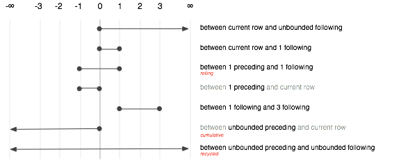

Из множества возможных спецификаций есть только три, которые обычно используются. Они выбирают между вариантами агрегирования:

- Рециклирующим: `BETWEEN UNBOUND PRECEEDING AND UNBOUND FOLLOWING`
- Кумулятивным: `BETWEEN UNBOUND PRECEEDING AND CURRENT ROW`
- Скользящим: `BETWEEN 2 PRECEEDING AND 2 FOLLOWING`

dplyr создает условие фрейма на основании того, используете ли вы рециклирующее или кумулятивное агрегирование.

Проще всего понять эти спецификации, глядя на несколько примеров. Простые примеры требуют только условия разделения и порядка:

- Ранжировать каждый год для игрока по числу хоумранов: `RANK() OVER (PARTITION BY playerID ORDER BY desc(H))`
- Рассчитать изменение числа игр от одного года до следующего: `G - LAG(G) OVER (PARTITION G playerID ORDER BY yearID)`

Агрегирующие варианты более многословным, потому что мы также должны задать условие фрейма:

- Скользящая сумма G по каждому игроку: `SUM(G) OVER (PARTITION BY playerID ORDER BY yearID BETWEEN UNBOUND PRECEEDING AND CURRENT ROW)`
- Вычисление “карьерных лет”: `YearID - min(YearID) OVER (PARTITION BY playerID BETWEEN UNBOUND PRECEEDING AND UNBOUND FOLLOWING) + 1`
- Вычисление скользящего среднего сыгранных игр: `MEAN(G) OVER (PARTITION BY playerID ORDER BY yearID BETWEEN 2 PRECEEDING AND 2 FOLLOWING)`

Вы заметите, что оконные функции в SQL более многословны, чем в R. Это потому, что различные оконные функции могут иметь различные разделы, и спецификация фрейма является более общей, чем два варианта агрегирования (рециклирующее и кумулятивное), предоставляемые dplyr. dplyr реализует компромисс: вы не можете получить доступ к редко используемым возможностям оконных функций (если вы не напишете сырой SQL), но зато основные операции гораздо более лаконичны.

### Трансляция dplyr в SQL

Чтобы увидеть, как отдельные оконные функции транслируются в SQL, мы можем использовать `translate_sql()` с аргументом `window = TRUE`.

```r
if (has_lahman("postgres")) {
  players_db <- group_by(tbl(lahman_postgres(), "Batting"), playerID)

  print(translate_sql(mean(G), tbl = players_db, window = TRUE))
  print(translate_sql(cummean(G), tbl = players_db, window = TRUE))
  print(translate_sql(rank(G), tbl = players_db, window = TRUE))
  print(translate_sql(ntile(G, 2), tbl = players_db, window = TRUE))
  print(translate_sql(lag(G), tbl = players_db, window = TRUE))
}
```

Если таблица была предварительно упорядочена, упорядочивание будет использовано для условия порядка:

```r
if (has_lahman("postgres")) {
  players_by_year <- arrange(players_db, yearID)
  print(translate_sql(cummean(G), tbl = players_by_year, window = TRUE))
  print(translate_sql(rank(), tbl = players_by_year, window = TRUE))
  print(translate_sql(lag(G), tbl = players_by_year, window = TRUE))
}
```

Есть определенные проблемы при трансляции функций между R и SQL, потому что dplyr старается по возможности сохранять оконные функции похожими на существующие аналоги в R и SQL. Это означает, что есть три способа управления условием порядка в зависимости от используемой оконной функции:

- Для ранжирующих функций упорядочивающая переменная является первым аргументом: `rank(x)`, `ntile(y, 2)`. Если опущен или равен `NULL`, будет использоваться порядок по умолчанию, связанный с таблицей (как задано `arrange())`).
- Аккумулирующие агрегирования принимают единственный аргумент (вектор для агрегирования). Для управления порядком используйте `order_by()`.
- Агрегирования, реализованные в dplyr (`lead`, `lag`, `nth_value`, `first_value`, `last_value`), имеют аргумент `order_by`. Его установка переопределяет порядок по умолчанию.

Эти три варианта показаны во фрагменте ниже:

```r
mutate(players,
  min_rank(yearID),
  order_by(yearID, cumsum(G)),
  lead(order_by = yearID, G)
)
```

В настоящее время нет способа для упорядочивания по множеству переменных, за исключением установки порядка по умолчанию при помощи `arrange()`. Он будет добавлен в будущем релизе.

### Трансляция фильтров на основе оконных функций

Есть некоторые ограничения оконных функций в SQL, которые делают их использование с `WHERE` сложным. Возьмём этот простой пример, где мы хотим найти год, когда каждый игрок сыграл больше всего игр:

```r
filter(players, rank(G) == 1)
```

Следующая простая трансляция не работает, потому что оконные функции допускаются только в `SELECT` и `ORDER_BY`.

```r
SELECT *
FROM Batting
WHERE rank() OVER (PARTITION BY "playerID" ORDER BY "G") = 1;
```

Вычисление оконной функции в `SELECT` и обращение к ней в `WHERE` или `HAVING` не работает, потому что `WHERE` и `HAVING` вычисляются перед оконной функцией.

```r
SELECT *, rank() OVER (PARTITION BY "playerID" ORDER BY "G") as rank
FROM Batting
WHERE rank = 1;

SELECT *, rank() OVER (PARTITION BY "playerID" ORDER BY "G") as rank
FROM Batting
HAVING rank = 1;
```

Вместо этого, мы должны использовать подзапрос:

```r
SELECT *
FROM (
  SELECT *, rank() OVER (PARTITION BY "playerID" ORDER BY "G") as rank
  FROM Batting
) tmp
WHERE rank = 1;
```

И даже этот запрос является упрощением, потому что к исходному столбцу также будет добавлен столбец с рангами. dplyr заботится о создании полного, подробного запроса, так что вы можете сосредоточиться на ваших проблемах анализа данных.